# SAP - projekt

Luka Babić, JMBAG: 0036538016

2024-01-18

# DODATNA ISTRAŽIVAČKA PITANJA

## Analiza utjecaja vrste goriva na cijenu i potrošnju: Kako vrsta goriva (benzin ili dizel) utječe na potrošnju goriva i cijenu automobila?

## 1. Učitavanje i filtriranje podataka:

```r
podaci <- read.csv("C:/Users/Babbage/Desktop/5semestar/sap/sapProjekt/car_specifications.csv")

# Ako imate podatke o potrošnji goriva u gradu i na autocesti, filtrirajte samo relevantne varijable
podaci_gorivo <- podaci %>% select(fuel, price, `city.L.100km`, `highway.L.100km`)
```

## 2. Deskriptivna statistika:

```r
# Ispisivanje prvih nekoliko redaka
head(podaci_gorivo)

# Istraživanje osnovnih statističkih mjera za cijenu i potrošnju goriva prema vrsti goriva
summary(podaci_gorivo$price)
summary(podaci_gorivo$`city.L.100km`)
summary(podaci_gorivo$`highway.L.100km`)
```

```
##     fuel price city.L.100km highway.L.100km
## 1 petrol 13495        11.19            8.70
## 2 petrol 16500        11.19            8.70
## 3 petrol 16500        12.37            9.04
## 4 petrol 13950         9.79            7.83
## 5 petrol 17450        13.06           10.68
## 6 petrol 15250        12.37            9.40
##    Min. 1st Qu.  Median    Mean 3rd Qu.    Max.
##    5118    7775   10295   13207   16500   45400
##    Min. 1st Qu.  Median    Mean 3rd Qu.    Max.
##   4.800   7.830   9.790   9.944  12.370  18.080
##    Min. 1st Qu.  Median    Mean 3rd Qu.    Max.
##   4.350   6.910   7.830   8.043   9.400  14.690
```

## 3. Vizualizacija:

### 3.1. Vizualizacija razlika u cijeni prema vrsti goriva

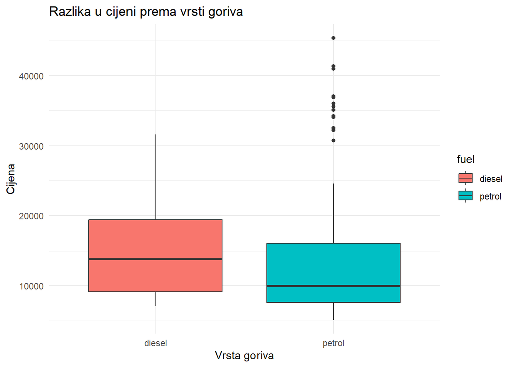

```r
ggplot(podaci_gorivo, aes(x = fuel, y = price, fill = fuel)) +
  geom_boxplot() +
  labs(title = "Razlika u cijeni prema vrsti goriva",
       x = "Vrsta goriva",
       y = "Cijena") +
  theme_minimal()
```

### 3.2. Vizualizacija razlika u potrošnji u gradu prema vrsti goriva

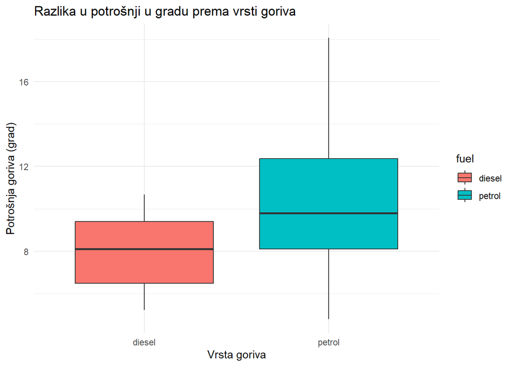

```r
ggplot(podaci_gorivo, aes(x = fuel, y = `city.L.100km`, fill = fuel)) +
  geom_boxplot() +
  labs(title = "Razlika u potrošnji u gradu prema vrsti goriva",
       x = "Vrsta goriva",
       y = "Potrošnja goriva (grad)") +
  theme_minimal()
```

### 3.3. Vizualizacija razlika u potrošnji na autocesti prema vrsti goriva

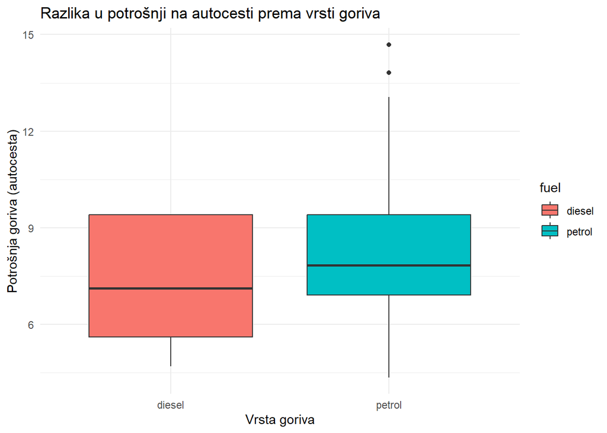

```r
ggplot(podaci_gorivo, aes(x = fuel, y = `highway.L.100km`, fill = fuel)) +
  geom_boxplot() +
  labs(title = "Razlika u potrošnji na autocesti prema vrsti goriva",
       x = "Vrsta goriva",
       y = "Potrošnja goriva (autocesta)") +
  theme_minimal()
```

## 4. Statistički testovi:

### 4.1. Testiranje razlika u cijeni između vrsti goriva (ANOVA)

```r
anova_model <- aov(price ~ fuel, data = podaci_gorivo)
summary(anova_model)
```

```
##              Df    Sum Sq   Mean Sq F value Pr(>F)
## fuel          1 1.537e+08 153743226   2.452  0.119
## Residuals   199 1.248e+10  62700651
```

### 4.2. Testiranje razlika u potrošnji u gradu između vrsti goriva (ANOVA)

```r
anova_model_city <- aov(`city.L.100km` ~ fuel, data = podaci_gorivo)
summary(anova_model_city)
```

```
##              Df Sum Sq Mean Sq F value   Pr(>F)
## fuel          1   74.9   74.87    12.3 0.000559 ***
## Residuals   199 1211.0    6.09
## ---
## Signif. codes:  0 '***' 0.001 '**' 0.01 '*' 0.05 '.' 0.1 ' ' 1
```

### 4.3. Testiranje razlika u potrošnji na autocesti između vrsti goriva (npr. ANOVA)

```r
anova_model_highway <- aov(`highway.L.100km` ~ fuel, data = podaci_gorivo)
summary(anova_model_highway)
```

```
##              Df Sum Sq Mean Sq F value Pr(>F)
## fuel          1   16.9  16.866   5.076 0.0253 *
## Residuals   199  661.2   3.323
## ---
## Signif. codes:  0 '***' 0.001 '**' 0.01 '*' 0.05 '.' 0.1 ' ' 1
```

## 5. Zaključak:

Na temelju rezultata ANOVA testova za usporedbu razlika u cijeni, potrošnji goriva u gradu i potrošnji goriva na autocesti između benzinskih i dizelskih automobila, možemo izvesti sljedeće zaključke:

1. Cijena: Rezultati ANOVA testa za cijenu automobila pokazuju da nema statistički značajne razlike u cijeni između benzinskih i dizelskih automobila (p-vrijednost = 0.119 > 0.05). Stoga, na temelju ovih rezultata, ne možemo zaključiti da vrsta goriva značajno utječe na cijenu automobila.
2. Potrošnja u gradu: ANOVA test za potrošnju goriva u gradu pokazuje da postoji statistički značajna razlika između benzinskih i dizelskih automobila (p-vrijednost = 0.000559 < 0.05). Ova razlika sugerira da vrsta goriva ima utjecaj na potrošnju goriva u gradu. Preciznije, rezultati upućuju na to da postoji značajna razlika u prosječnim vrijednostima potrošnje goriva u gradu između benzinskih i dizelskih automobila.
3. Potrošnja na autocesti: ANOVA test za potrošnju goriva na autocesti također pokazuje statistički značajnu razliku između benzinskih i dizelskih automobila (p-vrijednost = 0.0253 < 0.05). To sugerira da vrsta goriva ima utjecaj na potrošnju goriva na autocesti. Analogno rezultatima za potrošnju u gradu, možemo zaključiti da postoji značajna razlika u prosječnim vrijednostima potrošnje goriva na autocesti između benzinskih i dizelskih automobila.

U zaključku, ovisno o varijablama koje analizirate, vrsta goriva može imati značajan utjecaj na potrošnju goriva (u gradu i na autocesti), ali ne nužno i na cijenu automobila.